# Data Analytics for Business

## Session 2-3, Dimensionality Reduction and Derived Attributes (Technical Slides)

T. Evgeniou  
INSEAD

## Why this class? Three goals

1. Organizational Level: Develop your intuition about identifying data analytics opportunities and their implementation challenges
2. Project Level: Learn how to approach data analytics projects
3. Analysis Level: Learn how to perform, read, and use key data analytics methods.

## Data Analytics Processes: Iterative Process Cycle with a Lifetime

Step 1: Defining the Objective(s)

Step 2: Data Preparation and Exploration

Step 3: Analysis

Step 4: Performance Assessment

## What is Dimensionality Deduction and Factor Analysis?

Derive new variables which are (linear) combinations of the original ones and capture most of the information in the original data.

Is often used as a first step in Data Analytics

Can also be used to solve multicollinearity issues in regression

## Factor Analysis: Key idea

1. Transform the original selected variables into a smaller set of factors
2. Understand the underlying structure of the data and the new factors
3. Use the factors for subsequent analysis

## Key Questions

1. Can we really simplify the data by grouping the raw attributes?
2. How many factors should we use?
3. How good are the factors we found?
4. How interpretable and actionable are the factors we found?

## Dimensionality Reduction and Factor Analysis: 6 (Easy) Steps

1. Confirm the data is metric
2. Decide whether to scale or standardize the data
3. Check the correlation matrix to see if Factor Analysis makes sense
4. Develop a scree plot and decide on the number of factors to be derived
5. Interpret the factors (consider factor rotations - technical but useful)
6. Save factor scores for subsequent analyses

## Applying Factor Analysis: Evaluating MBA Applications

Variables available:

- GPA
- GMAT score
- Scholarships, fellowships won
- Evidence of Communications skills
- Prior Job Experience
- Organizational Experience
- Other extra curricular achievements

Which variables are correlated? What do these variables capture?

## Data Standardization: Example Code

```r
ProjectDatafactor_scaled=apply(ProjectDataFactor,2, function(r) {
  if (sd(r)!=0) {
    res=(r-mean(r))/sd(r)
    } else {
      res=0*r; res
      }
  })
```

## Step 3: Check correlation matrix to see if Factor Analysis makes sense

|  | Q1_1_When buying a boat I do a lot of shopping around and visit multiple dealers | Q1_2_When buying a boat getting the lowest price is more important than the boat brand | Q1_3_The brand of boat I buy says a lot about who I am | Q1_4_I only consider buying a boat from a reputable brand | Q1_5_I am willing to pay a premium for a brand with a reputation for high quality | Q1_6_Owning a boat is a way of rewarding myself for my hard work | Q1_7_Owning a boat gives me a sense of achievement | Q1_8_When buying a boat functionality is more important than style | Q1_9_I see my boat as a status symbol | Q1_10_When buying a boat I rely more on expert opinion than my own e g consumer reports salespeople | Q1_11_I tend to perform minor boat repairs and maintenance on my own | Q1_12_When it comes to boating I tend to prefer a basic boat with little to no frills | Q1_13_When buying a boat I tend to buy the latest and greatest | Q1_14_When buying accessories for my boat I tend to buy the latest and greatest | Q1_15_I am serious about the technology on my boat | Q1_16_People tend to come to me for advice about boating | Q1_17_I consider myself more knowledgeable about boating than the rest of my boating peers | Q1_18_Boating gives me a feeling of adventure | Q1_19_Boating allows me to experience nature | Q1_20_When not on my boat I often find myself doing boating related activities | Q1_21_Boating helps me escape from everyday life and relax | Q1_22_Boating helps me stay active | Q1_23_Boating allows me to excel in the sports that I am passionate about e g fishing racing water sports | Q1_24_Boating gives me an outlet to socialize with family and or friends | Q1_25_Being in charge of my boat is very important to me | Q1_26_Having a powerful boat is what is most important to me | Q1_27_Boating is the number one thing I do with my spare time | Q1_28_Boating is my true passion in life | Q1_29_Boating is one of many things I do in my spare time |
| --- | --- | --- | --- | --- | --- | --- | --- | --- | --- | --- | --- | --- | --- | --- | --- | --- | --- | --- | --- | --- | --- | --- | --- | --- | --- | --- | --- | --- | --- |
| Q1_1_When buying a boat I do a lot of shopping around and visit multiple dealers | 1.00 | 0.01 | 0.11 | 0.20 | 0.18 | 0.27 | 0.18 | 0.09 | 0.08 | 0.11 | 0.14 | -0.05 | 0.12 | 0.18 | 0.26 | 0.16 | 0.15 | 0.25 | 0.27 | 0.19 | 0.24 | 0.23 | 0.19 | 0.21 | 0.23 | 0.10 | 0.13 | 0.18 | 0.20 |
| Q1_2_When buying a boat getting the lowest price is more important than the boat brand | 0.01 | 1.00 | -0.03 | -0.21 | -0.21 | -0.04 | 0.02 | 0.20 | 0.09 | 0.16 | 0.04 | 0.37 | 0.01 | -0.03 | -0.08 | -0.02 | 0.04 | -0.04 | -0.04 | 0.05 | -0.10 | -0.08 | 0.00 | -0.08 | 0.01 | 0.07 | 0.05 | 0.02 | -0.03 |
| Q1_3_The brand of boat I buy says a lot about who I am | 0.11 | -0.03 | 1.00 | 0.26 | 0.40 | 0.34 | 0.44 | -0.05 | 0.58 | 0.14 | 0.10 | -0.09 | 0.48 | 0.46 | 0.38 | 0.39 | 0.38 | 0.24 | 0.14 | 0.39 | 0.18 | 0.28 | 0.34 | 0.23 | 0.36 | 0.47 | 0.40 | 0.43 | 0.17 |
| Q1_4_I only consider buying a boat from a reputable brand | 0.20 | -0.21 | 0.26 | 1.00 | 0.37 | 0.20 | 0.18 | 0.00 | 0.17 | 0.10 | 0.06 | -0.16 | 0.27 | 0.29 | 0.30 | 0.18 | 0.17 | 0.18 | 0.19 | 0.18 | 0.18 | 0.23 | 0.16 | 0.23 | 0.22 | 0.19 | 0.17 | 0.21 | 0.19 |
| Q1_5_I am willing to pay a premium for a brand with a reputation for high quality | 0.18 | -0.21 | 0.40 | 0.37 | 1.00 | 0.29 | 0.29 | -0.03 | 0.33 | 0.14 | 0.07 | -0.17 | 0.45 | 0.46 | 0.42 | 0.36 | 0.32 | 0.23 | 0.18 | 0.32 | 0.19 | 0.27 | 0.29 | 0.25 | 0.29 | 0.34 | 0.29 | 0.33 | 0.18 |
| Q1_6_Owning a boat is a way of rewarding myself for my hard work | 0.27 | -0.04 | 0.34 | 0.20 | 0.29 | 1.00 | 0.55 | 0.04 | 0.35 | 0.12 | 0.15 | -0.12 | 0.29 | 0.31 | 0.31 | 0.27 | 0.24 | 0.44 | 0.36 | 0.35 | 0.42 | 0.41 | 0.32 | 0.37 | 0.42 | 0.31 | 0.34 | 0.39 | 0.27 |
| Q1_7_Owning a boat gives me a sense of achievement | 0.18 | 0.02 | 0.44 | 0.18 | 0.29 | 0.55 | 1.00 | -0.01 | 0.49 | 0.12 | 0.12 | -0.11 | 0.35 | 0.36 | 0.34 | 0.31 | 0.29 | 0.40 | 0.28 | 0.36 | 0.33 | 0.39 | 0.30 | 0.33 | 0.42 | 0.39 | 0.37 | 0.40 | 0.24 |
| Q1_8_When buying a boat functionality is more important than style | 0.09 | 0.20 | -0.05 | 0.00 | -0.03 | 0.04 | -0.01 | 1.00 | -0.09 | 0.09 | 0.14 | 0.24 | -0.05 | -0.02 | 0.06 | 0.02 | 0.05 | 0.07 | 0.09 | 0.04 | 0.06 | 0.05 | 0.10 | 0.02 | 0.10 | -0.04 | 0.03 | 0.05 | 0.10 |
| Q1_9_I see my boat as a status symbol | 0.08 | 0.09 | 0.58 | 0.17 | 0.33 | 0.35 | 0.49 | -0.09 | 1.00 | 0.14 | 0.06 | -0.04 | 0.48 | 0.43 | 0.33 | 0.39 | 0.37 | 0.22 | 0.07 | 0.37 | 0.14 | 0.23 | 0.29 | 0.23 | 0.32 | 0.50 | 0.40 | 0.40 | 0.11 |
| Q1_10_When buying a boat I rely more on expert opinion than my own e g consumer reports salespeople | 0.11 | 0.16 | 0.14 | 0.10 | 0.14 | 0.12 | 0.12 | 0.09 | 0.14 | 1.00 | -0.09 | 0.12 | 0.16 | 0.11 | 0.11 | -0.03 | -0.03 | 0.14 | 0.09 | 0.10 | 0.08 | 0.09 | 0.07 | 0.13 | 0.08 | 0.13 | 0.08 | 0.07 | 0.05 |
| Q1_11_I tend to perform minor boat repairs and maintenance on my own | 0.14 | 0.04 | 0.10 | 0.06 | 0.07 | 0.15 | 0.12 | 0.14 | 0.06 | -0.09 | 1.00 | 0.09 | 0.08 | 0.13 | 0.20 | 0.32 | 0.31 | 0.11 | 0.12 | 0.25 | 0.13 | 0.17 | 0.19 | 0.08 | 0.25 | 0.09 | 0.16 | 0.18 | 0.17 |
| Q1_12_When it comes to boating I tend to prefer a basic boat with little to no frills | -0.05 | 0.37 | -0.09 | -0.16 | -0.17 | -0.12 | -0.11 | 0.24 | -0.04 | 0.12 | 0.09 | 1.00 | -0.11 | -0.17 | -0.17 | -0.02 | 0.02 | -0.12 | -0.09 | 0.01 | -0.17 | -0.11 | -0.03 | -0.17 | -0.05 | -0.06 | 0.00 | -0.01 | -0.04 |
| Q1_13_When buying a boat I tend to buy the latest and greatest | 0.12 | 0.01 | 0.48 | 0.27 | 0.45 | 0.29 | 0.35 | -0.05 | 0.48 | 0.16 | 0.08 | -0.11 | 1.00 | 0.64 | 0.46 | 0.43 | 0.43 | 0.20 | 0.11 | 0.39 | 0.14 | 0.23 | 0.32 | 0.20 | 0.32 | 0.48 | 0.40 | 0.40 | 0.19 |
| Q1_14_When buying accessories for my boat I tend to buy the latest and greatest | 0.18 | -0.03 | 0.46 | 0.29 | 0.46 | 0.31 | 0.36 | -0.02 | 0.43 | 0.11 | 0.13 | -0.17 | 0.64 | 1.00 | 0.50 | 0.43 | 0.40 | 0.25 | 0.18 | 0.41 | 0.21 | 0.29 | 0.36 | 0.21 | 0.35 | 0.46 | 0.39 | 0.40 | 0.21 |
| Q1_15_I am serious about the technology on my boat | 0.26 | -0.08 | 0.38 | 0.30 | 0.42 | 0.31 | 0.34 | 0.06 | 0.33 | 0.11 | 0.20 | -0.17 | 0.46 | 0.50 | 1.00 | 0.41 | 0.39 | 0.32 | 0.26 | 0.41 | 0.21 | 0.33 | 0.35 | 0.27 | 0.43 | 0.37 | 0.35 | 0.38 | 0.24 |
| Q1_16_People tend to come to me for advice about boating | 0.16 | -0.02 | 0.39 | 0.18 | 0.36 | 0.27 | 0.31 | 0.02 | 0.39 | -0.03 | 0.32 | -0.02 | 0.43 | 0.43 | 0.41 | 1.00 | 0.63 | 0.20 | 0.14 | 0.52 | 0.16 | 0.30 | 0.40 | 0.19 | 0.39 | 0.40 | 0.48 | 0.50 | 0.20 |
| Q1_17_I consider myself more knowledgeable about boating than the rest of my boating peers | 0.15 | 0.04 | 0.38 | 0.17 | 0.32 | 0.24 | 0.29 | 0.05 | 0.37 | -0.03 | 0.31 | 0.02 | 0.43 | 0.40 | 0.39 | 0.63 | 1.00 | 0.17 | 0.12 | 0.45 | 0.13 | 0.26 | 0.36 | 0.15 | 0.36 | 0.40 | 0.44 | 0.46 | 0.21 |
| Q1_18_Boating gives me a feeling of adventure | 0.25 | -0.04 | 0.24 | 0.18 | 0.23 | 0.44 | 0.40 | 0.07 | 0.22 | 0.14 | 0.11 | -0.12 | 0.20 | 0.25 | 0.32 | 0.20 | 0.17 | 1.00 | 0.49 | 0.28 | 0.47 | 0.44 | 0.29 | 0.42 | 0.37 | 0.24 | 0.25 | 0.31 | 0.30 |
| Q1_19_Boating allows me to experience nature | 0.27 | -0.04 | 0.14 | 0.19 | 0.18 | 0.36 | 0.28 | 0.09 | 0.07 | 0.09 | 0.12 | -0.09 | 0.11 | 0.18 | 0.26 | 0.14 | 0.12 | 0.49 | 1.00 | 0.21 | 0.44 | 0.38 | 0.24 | 0.37 | 0.32 | 0.14 | 0.18 | 0.23 | 0.28 |
| Q1_20_When not on my boat I often find myself doing boating related activities | 0.19 | 0.05 | 0.39 | 0.18 | 0.32 | 0.35 | 0.36 | 0.04 | 0.37 | 0.10 | 0.25 | 0.01 | 0.39 | 0.41 | 0.41 | 0.52 | 0.45 | 0.28 | 0.21 | 1.00 | 0.23 | 0.33 | 0.40 | 0.24 | 0.41 | 0.40 | 0.50 | 0.52 | 0.25 |
| Q1_21_Boating helps me escape from everyday life and relax | 0.24 | -0.10 | 0.18 | 0.18 | 0.19 | 0.42 | 0.33 | 0.06 | 0.14 | 0.08 | 0.13 | -0.17 | 0.14 | 0.21 | 0.21 | 0.16 | 0.13 | 0.47 | 0.44 | 0.23 | 1.00 | 0.42 | 0.24 | 0.42 | 0.30 | 0.15 | 0.24 | 0.26 | 0.29 |
| Q1_22_Boating helps me stay active | 0.23 | -0.08 | 0.28 | 0.23 | 0.27 | 0.41 | 0.39 | 0.05 | 0.23 | 0.09 | 0.17 | -0.11 | 0.23 | 0.29 | 0.33 | 0.30 | 0.26 | 0.44 | 0.38 | 0.33 | 0.42 | 1.00 | 0.34 | 0.38 | 0.37 | 0.23 | 0.35 | 0.38 | 0.34 |
| Q1_23_Boating allows me to excel in the sports that I am passionate about e g fishing racing water sports | 0.19 | 0.00 | 0.34 | 0.16 | 0.29 | 0.32 | 0.30 | 0.10 | 0.29 | 0.07 | 0.19 | -0.03 | 0.32 | 0.36 | 0.35 | 0.40 | 0.36 | 0.29 | 0.24 | 0.40 | 0.24 | 0.34 | 1.00 | 0.23 | 0.32 | 0.33 | 0.39 | 0.44 | 0.23 |
| Q1_24_Boating gives me an outlet to socialize with family and or friends | 0.21 | -0.08 | 0.23 | 0.23 | 0.25 | 0.37 | 0.33 | 0.02 | 0.23 | 0.13 | 0.08 | -0.17 | 0.20 | 0.21 | 0.27 | 0.19 | 0.15 | 0.42 | 0.37 | 0.24 | 0.42 | 0.38 | 0.23 | 1.00 | 0.31 | 0.21 | 0.24 | 0.25 | 0.27 |
| Q1_25_Being in charge of my boat is very important to me | 0.23 | 0.01 | 0.36 | 0.22 | 0.29 | 0.42 | 0.42 | 0.10 | 0.32 | 0.08 | 0.25 | -0.05 | 0.32 | 0.35 | 0.43 | 0.39 | 0.36 | 0.37 | 0.32 | 0.41 | 0.30 | 0.37 | 0.32 | 0.31 | 1.00 | 0.34 | 0.35 | 0.40 | 0.23 |
| Q1_26_Having a powerful boat is what is most important to me | 0.10 | 0.07 | 0.47 | 0.19 | 0.34 | 0.31 | 0.39 | -0.04 | 0.50 | 0.13 | 0.09 | -0.06 | 0.48 | 0.46 | 0.37 | 0.40 | 0.40 | 0.24 | 0.14 | 0.40 | 0.15 | 0.23 | 0.33 | 0.21 | 0.34 | 1.00 | 0.45 | 0.47 | 0.15 |
| Q1_27_Boating is the number one thing I do with my spare time | 0.13 | 0.05 | 0.40 | 0.17 | 0.29 | 0.34 | 0.37 | 0.03 | 0.40 | 0.08 | 0.16 | 0.00 | 0.40 | 0.39 | 0.35 | 0.48 | 0.44 | 0.25 | 0.18 | 0.50 | 0.24 | 0.35 | 0.39 | 0.24 | 0.35 | 0.45 | 1.00 | 0.62 | 0.23 |
| Q1_28_Boating is my true passion in life | 0.18 | 0.02 | 0.43 | 0.21 | 0.33 | 0.39 | 0.40 | 0.05 | 0.40 | 0.07 | 0.18 | -0.01 | 0.40 | 0.40 | 0.38 | 0.50 | 0.46 | 0.31 | 0.23 | 0.52 | 0.26 | 0.38 | 0.44 | 0.25 | 0.40 | 0.47 | 0.62 | 1.00 | 0.26 |
| Q1_29_Boating is one of many things I do in my spare time | 0.20 | -0.03 | 0.17 | 0.19 | 0.18 | 0.27 | 0.24 | 0.10 | 0.11 | 0.05 | 0.17 | -0.04 | 0.19 | 0.21 | 0.24 | 0.20 | 0.21 | 0.30 | 0.28 | 0.25 | 0.29 | 0.34 | 0.23 | 0.27 | 0.23 | 0.15 | 0.23 | 0.26 | 1.00 |

## Step 4. Develop a scree plot and decide on the number of factors to be derived

For the method considered here (Principal Component Analysis):

- If there are n variables we will have n factors in total
- First factor will explain most of the variance, second next and so on.

Eigenvalues and Variance Explained by Factors

- each factor will have an associated eigenvalue - which corresponds to the amount of variance explained by that factor
- with standardized variables each variable has a variance of 1, and the sum of all eigenvalues with n raw attributes is n
- we would like to capture as much of the total variance as possible, while keeping as few factors as possible

## How many factors?

Three criteria to use:

- Eigenvalue > 1
- Cumulative variance explained
- "Elbow" in the Scree plot

## What Factor Loads "Look Good"? Three Technical Quality Criteria

1. For each factor (column) only a few loadings are large (in absolute value)
2. For each raw attribute (row) only a few loadings are large (in absolute value)
3. Any pair of factors (columns) should have different "patterns" of loading

## Factor Analysis: Some (Technical) Concepts

1. Correlation
2. Variance explained (eigenvalues)
3. Scree plot
4. varimax rotation
5. Factor Loadings ("components")
6. Factor scores

## Key Questions

1. How many factors should we use? Why? Quantitative and Qualitative criteria
2. How can we name and interpret the factors?
3. What are some issues to consider?

## Next Class: Cluster Analysis for Segmentation

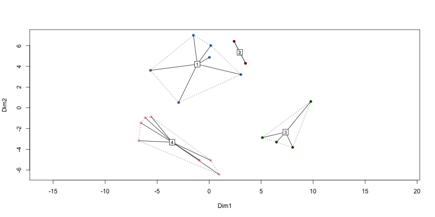